# Лабораторна робота 6. Метод головних компонент. Метричні методи класифікації

### Дисципліна: Розпізнавання образів та комп'ютерний зір

### Група: КІ-22-1

### Студент: Савченко Андрій Олександрович

## Завдання для самостійної роботи

### 1. Імопртувати декілька власних довільних зображень, вклчаючи і власне фото.

### 2. Стиснути його в 20, 30, 50 разів, як показано в прикладах. ВИвести і прокоментувати результати.

### 3. Побудувати kNN-класифікатор згідно з заданим варіантом без використання віонних функцій і з використанням вікна Парзена. Проаналізувати результати.

### 4. Дати відповіді на контрольні запитання.

### 5. Відправити результати роботи у файлі lab_6_StudentLastName.ipynb до віддаленого репозиторію на GіtHub

## Варіанти індивідульних завдань

### 1 - 2 завдання

```
Обробка зображення: My.jpg
k=20: коефіцієнт стиснення ≈ 55.53x
k=30: коефіцієнт стиснення ≈ 37.02x
k=50: коефіцієнт стиснення ≈ 22.21x
```

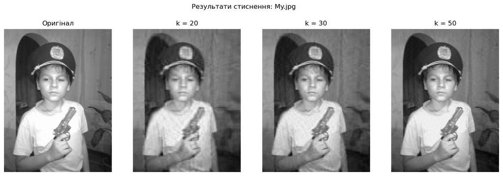

```
Обробка зображення: My1.jpg
k=20: коефіцієнт стиснення ≈ 55.53x
k=30: коефіцієнт стиснення ≈ 37.02x
k=50: коефіцієнт стиснення ≈ 22.21x
```

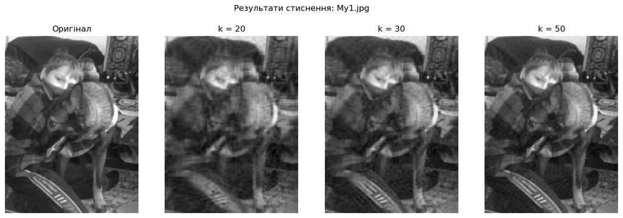

```
Обробка зображення: My2.jpg
k=20: коефіцієнт стиснення ≈ 55.53x
k=30: коефіцієнт стиснення ≈ 37.02x
k=50: коефіцієнт стиснення ≈ 22.21x
```

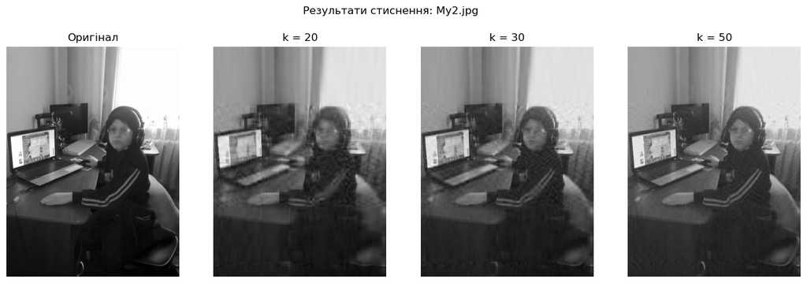

```
АНАЛІЗ РЕЗУЛЬТАТІВ:
1. При k = 20:
- сильне стиснення
- значна втрата деталей
- зображення розмите

2. При k = 30:
- краща якість
- збережені основні контури
- частково втрачаються дрібні деталі

3. При k = 50:
- висока якість зображення
- майже не відрізняється від оригіналу
- менший ступінь стиснення

ВИСНОВОК:
Метод SVD дозволяє ефективно стискати зображення.
Менше k - більше стиснення, але гірша якість.
Більше k - краща якість, але менше стиснення.
Оптимальне значення k забезпечує баланс між якістю та розміром.
```

```python
import numpy as np
import matplotlib.pyplot as plt
from matplotlib.image import imread

def to_grayscale(img):
    if len(img.shape) == 3:
        return np.mean(img, axis=2)
    return img

def compress_image(U, S, Vt, k):
    return U[:, :k] @ np.diag(S[:k]) @ Vt[:k, :]

def compression_ratio(img_shape, k):
    m, n = img_shape
    compressed_size = m*k + k + k*n
    original_size = m*n
    return original_size / compressed_size

image_files = [
    "My.jpg",
    "My1.jpg",
    "My2.jpg"
]

k_values = [20, 30, 50]

for file in image_files:
    print(f"\nОбробка зображення: {file}")

    img = imread(file)
    img = to_grayscale(img)

    U, S, Vt = np.linalg.svd(img, full_matrices=False)

    plt.figure(figsize=(16, 5))

    plt.subplot(1, 4, 1)
    plt.imshow(img, cmap='gray')
    plt.title("Оригінал")
    plt.axis('off')

    for i, k in enumerate(k_values):
        compressed = compress_image(U, S, Vt, k)

        plt.subplot(1, 4, i+2)
        plt.imshow(compressed, cmap='gray')
        plt.title(f"k = {k}")
        plt.axis('off')

        ratio = compression_ratio(img.shape, k)
        print(f"k={k}: коефіцієнт стиснення ≈ {ratio:.2f}x")

    plt.suptitle(f"Результати стиснення: {file}")
    plt.show()


print("\nАНАЛІЗ РЕЗУЛЬТАТІВ:")
print("1. При k = 20:")
print("- сильне стиснення")
print("- значна втрата деталей")
print("- зображення розмите")

print("\n2. При k = 30:")
print("- краща якість")
print("- збережені основні контури")
print("- частково втрачаються дрібні деталі")

print("\n3. При k = 50:")
print("- висока якість зображення")
print("- майже не відрізняється від оригіналу")
print("- менший ступінь стиснення")

print("\nВИСНОВОК:")
print("Метод SVD дозволяє ефективно стискати зображення.")
print("Менше k - більше стиснення, але гірша якість.")
print("Більше k - краща якість, але менше стиснення.")
print("Оптимальне значення k забезпечує баланс між якістю та розміром.")
```

### 3 завдання

Варіант 9:  
x_train_9:  
[[37 46]  
[26 50]  
[23 6]  
[21 33]  
[36 42]  
[37 44]  
[19 6]  
[23 5]  
[35 28]]  
y_train_9:  
[ 1 -1 1 1 -1 1 -1 1 1]

```
=== h = 5 ===
Predicted: [ 1 -1  1  1  1  1  1  1  1]
Accuracy: 0.7777777777777778
```

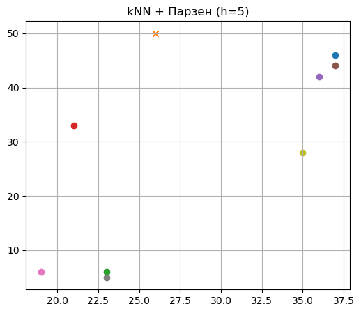

```
=== h = 10 ===
Predicted: [ 1 -1  1  1  1  1  1  1  1]
Accuracy: 0.7777777777777778
```

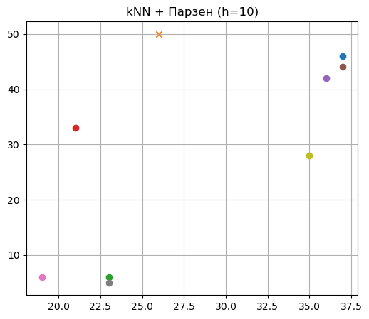

```
=== h = 15 ===
Predicted: [1 1 1 1 1 1 1 1 1]
Accuracy: 0.6666666666666666
```

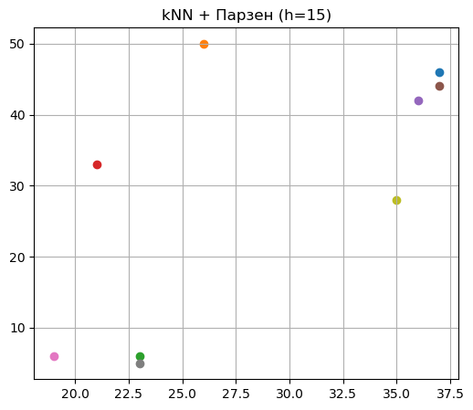

```
АНАЛІЗ РЕЗУЛЬТАТІВ:
1. Малий h (наприклад 5):
- враховуються тільки дуже близькі точки
- модель чутлива до шуму
- можливе переобучення

2. Середній h (10):
- баланс між локальністю і узагальненням
- зазвичай найкраща точність

3. Великий h (15):
- враховується більше точок
- модель згладжується
- можливе недообучення

ВИСНОВОК:
Метод kNN з вікном Парзена дозволяє враховувати вагу сусідів.
Параметр h визначає ширину вікна і сильно впливає на якість класифікації.
Оптимальне значення h забезпечує найкращий баланс між переобученням і узагальненням.
```

```python
import numpy as np
import matplotlib.pyplot as plt

x_train = np.array([
 [37,46],[26,50],[23,6],[21,33],[36,42],
 [37,44],[19,6],[23,5],[35,28]
])

y_train = np.array([1,-1,1,1,-1,1,-1,1,1])

def euclidean_distance(a, b):
    return np.sqrt(np.sum((a - b)**2))

def parzen_kernel(r, h):
    """Ядерна функція Парзена (прямокутне вікно)"""
    return 1 if r <= h else 0

def knn_parzen(x, X_train, y_train, k, h):
    distances = np.array([euclidean_distance(x, xi) for xi in X_train])

    idx = np.argsort(distances)[:k]

    weights = []
    for i in idx:
        w = parzen_kernel(distances[i], h)
        weights.append(w * y_train[i])

    return 1 if np.sum(weights) >= 0 else -1

k = 3
h_values = [5, 10, 15]

for h in h_values:
    print(f"\n=== h = {h} ===")

    y_pred = []
    for x in x_train:
        pred = knn_parzen(x, x_train, y_train, k, h)
        y_pred.append(pred)

    y_pred = np.array(y_pred)

    accuracy = np.mean(y_pred == y_train)
    print("Predicted:", y_pred)
    print("Accuracy:", accuracy)

    plt.figure(figsize=(6,5))

    for i in range(len(x_train)):
        if y_pred[i] == 1:
            plt.scatter(x_train[i][0], x_train[i][1])
        else:
            plt.scatter(x_train[i][0], x_train[i][1], marker='x')

    plt.title(f"kNN + Парзен (h={h})")
    plt.grid(True)
    plt.show()

print("\nАНАЛІЗ РЕЗУЛЬТАТІВ:")
print("1. Малий h (наприклад 5):")
print("- враховуються тільки дуже близькі точки")
print("- модель чутлива до шуму")
print("- можливе переобучення")

print("\n2. Середній h (10):")
print("- баланс між локальністю і узагальненням")
print("- зазвичай найкраща точність")

print("\n3. Великий h (15):")
print("- враховується більше точок")
print("- модель згладжується")
print("- можливе недообучення")

print("\nВИСНОВОК:")
print("Метод kNN з вікном Парзена дозволяє враховувати вагу сусідів.")
print("Параметр h визначає ширину вікна і сильно впливає на якість класифікації.")
print("Оптимальне значення h забезпечує найкращий баланс між переобученням і узагальненням.")
```

## Контрольні питання

### 1. У чому полягає ідея методу головних компонент (PCA)?

Ідея PCA (Principal Component Analysis) — знайти нову систему координат для даних, де перша вісь проходить у напрямку максимальної дисперсії (розкиду) даних, а кожна наступна вісь перпендикулярна до попередніх і теж максимізує залишок дисперсії.

### 2. Яким чином метод головних компонент використовується для зменшення розмірності даних?

Процес виглядає так:

1. Центруємо дані (віднімаємо середнє).
2. Обчислюємо матрицю коваріації.
3. Знаходимо власні числа ($\lambda$) та власні вектори цією матриці.
4. Сортуємо власні числа за спаданням.
5. Обираємо перші $k$ векторів. Проекція даних на ці $k$ векторів і буде результатом із меншою кількістю ознак.

### 3. Як пов’язані PCA та SVD? Як його можна використовувати для аналізу даних?

SVD (Singular Value Decomposition) — це матрична декомпозиція: $X = U \Sigma V^T$.  
Якщо дані центровані, то праві сингулярні вектори (матриця $V$) — це і є головні компоненти PCA.  
Обчислювати SVD чисельно стабільніше та швидше, ніж спочатку будувати матрицю коваріації $X^T X$, а потім шукати її власні вектори.

### 4. Які метрики якості використовуються в багатокласовій класифікації?

Macro рахує середнє по класах (важливо для рідкісних класів).  
Micro — загальне (важливо для загальної точності).  
Confusion Matrix (Матриця помилок) показує, які класи модель плутає найчастіше.  
Log-loss штрафує за впевненість у неправильній відповіді.

### 5. Чим відрізняються стратегії one-vs-all та all-vs-all у багатокласовій класифікації?

One-vs-All (або One-vs-Rest): Ми навчаємо $N$ класифікаторів (де $N$ — кількість класів). Кожен вирішує: «це клас $i$ чи ні?». Перемагає той, хто видав найбільшу ймовірність.  
All-vs-All: Ми навчаємо класифікатор для кожної пари класів. Всього $\frac{N(N-1)}{2}$ моделей. Перемагає клас, що набрав найбільше «голосів» у дуелях. Довше в навчанні, але іноді точніше.

### 6. Що таке гіпотеза компактності в метричних методах класифікації?

Це фундаментальне припущення метричних методів: схожі об'єкти (близькі в просторі ознак) частіше належать до одного класу. > Якщо ви бачите щось, що ходить як качка і крякає як качка, воно, ймовірно, знаходиться в «кластері» качок.

### 7. Як працює метод k-найближчих сусідів (kNN)? Які його переваги та недоліки?

Працює за принципом: «скажи мені, хто твої сусіди, і я скажу, хто ти». Клас об'єкта визначається більшістю голосів $k$ найближчих точок.  
Переваги: Простота, не потребує фази навчання (lazy learning).  
Недоліки: Чутливий до масштабу ознак, повільний при великій кількості даних, «прокляття розмірності».

### 8. У чому полягає суть методу парзенівського вікна? Які його недоліки та переваги?

Це вдосконалений kNN, де замість фіксованої кількості сусідів ми беремо фіксований радіус (вікно) $h$.  
Суть: Внесок кожного сусіда зважується функцією ядра $K$. Чим ближче сусід, тим більший його «голос».  
Переваги: Більш гладка межа розділення класів.  
Недоліки: Потрібно підбирати оптимальну ширину вікна $h$. Якщо $h$ мале — перенавчання, якщо велике — недонавчання.

### 9. У чому полягає суть методу потенційних функцій у метричних методах класифікації? Які його недоліки та переваги?

Розвиток парзенівського вікна. Кожен об'єкт навчальної вибірки розглядається як «джерело енергії» (заряд).  
Суть: Класифікація відбувається за сумарним потенціалом полів усіх зарядів.  
Переваги: Можна «навчати» модель, змінюючи ваги (заряди) точок, які часто помиляються.  
Недоліки: Складність підбору параметрів спадання потенціалу та ризик перенавчання.